# Leitura de dados no R

github.com/nacmarino/introducaoR

## Métodos tradicionais para leitura de dados

- Os métodos disponíveis no pacote base são:
  - `read.csv` para arquivos com células separadas por *vírgulas*, como um *.csv*
  - `read.table` para arquivos com células separadas por *tabulação*, como um *.txt*

## Argumentos da função read.table()

```r
args(read.table)
```

```
## function (file, header = FALSE, sep = "", quote = "\"'", dec = ".",
##     numerals = c("allow.loss", "warn.loss", "no.loss"), row.names,
##     col.names, as.is = !stringsAsFactors, na.strings = "NA",
##     colClasses = NA, nrows = -1, skip = 0, check.names = TRUE,
##     fill = !blank.lines.skip, strip.white = FALSE, blank.lines.skip = TRUE,
##     comment.char = "#", allowEscapes = FALSE, flush = FALSE,
##     stringsAsFactors = default.stringsAsFactors(), fileEncoding = "",
##     encoding = "unknown", text, skipNul = FALSE)
## NULL
```

## Métodos tradicionais para leitura de dados

- Os métodos tradicionais exigem alguns cuidados especiais para que os dados possam ser carregados adequadamente.
- *Maior parte dos erros de leitura de dados ocorrem por conta de erros na edição da planilha*.
  - "," no lugar de ".";
  - espaços entre palavras;
  - espaços no final de um célula;
  - células vazias;
  - acento e outras coisas do português;
  - caracteres especiais.

## Métodos tradicionais para leitura de dados

- Um exemplo.

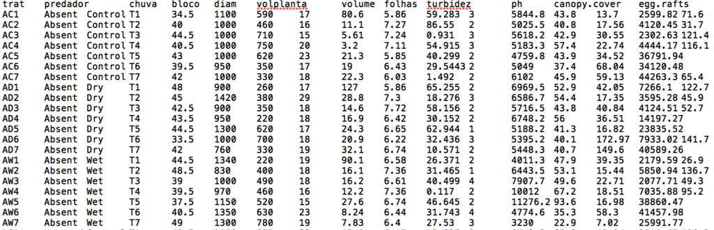

## Métodos tradicionais para leitura de dados

- Todo objeto criado ocupa um espaço, diretamente proporcional ao número de elementos no mesmo.

```r
# vamos simular um conjunto de dados
a <- rnorm(n = 10, mean = 0, sd = 1)
b <- rpois(n = 10, lambda = 6)
c <- rbinom(n = 10, size = 1, prob = 0.5)
```

```r
# vamos armazenar este conjunto de dados em um data.frame
dados_pequeno <- data.frame(a,b,c)
```

## Métodos tradicionais para leitura de dados

```r
format(object.size(dados_pequeno), units = "Mb")
```

```
## [1] "0 Mb"
```

```r
head(dados_pequeno)
```

```
##             a  b c
## 1 -0.07725278 10 1
## 2 -1.44455840  8 0
## 3 -1.66358243  8 1
## 4  0.50323146  3 1
## 5  0.06037292 10 1
## 6  0.62150870  3 0
```

## Métodos tradicionais para leitura de dados

```r
# agora, vamos simular um conjunto de dados maior ainda
x <- rnorm(n = 1e6, mean = 0, sd = 1)
y <- rpois(n = 1e6, lambda = 6)
z <- rbinom(n = 1e6, size = 1, prob = 0.5)
dados_grande <- data.frame(x,y,z)
```

```r
format(object.size(dados_grande), units = "Mb")
```

```
## [1] "15.3 Mb"
```

```r
str(dados_grande)
```

```
## 'data.frame':    1000000 obs. of  3 variables:
##  $ x: num  0.8714 -0.0601 0.3476 -0.1531 1.4132 ...
##  $ y: int  1 3 5 2 6 4 7 5 3 6 ...
##  $ z: int  1 0 1 0 0 0 0 0 0 0 ...
```

## Métodos tradicionais para leitura de dados

- Quanto maior o objeto, mais lenta é a sua exportação, importação, leitura e processamento

```r
system.time(write.table(dados_pequeno, "dados/dados_pequeno.txt",
                        sep = "\t", row.names = FALSE))
```

```
##    user  system elapsed
##   0.001   0.000   0.002
```

```r
system.time(write.table(dados_grande, "dados/dados_grande.txt",
                        sep = "\t", row.names = FALSE))
```

```
##    user  system elapsed
##   1.855   0.053   1.930
```

## Métodos tradicionais para leitura de dados

- Quanto maior o objeto, mais lenta é a sua exportação, importação, leitura e processamento

```r
system.time(read.table("dados/dados_pequeno.txt", header = TRUE))
```

```
##    user  system elapsed
##   0.002   0.000   0.001
```

```r
system.time(read.table("dados/dados_grande.txt", header = TRUE))
```

```
##    user  system elapsed
##   4.249   0.084   4.349
```

## Alternativas para leitura de dados

- Existem métodos alternativos para a leitura de dados que:
  - permitem a leitura de outras extensões;
  - são capazes de ler dados sem a necessidade de edições prévias;
  - são bem mais rápidos na importação e processamento de planilhas.

## O pacote readxl

- Criado por Hadley Wickham (cientista chefe do RStudio);
- Possui apenas duas funções:
  - `read_excel`, para ler uma aba de um arquivo com extensão *".xlsx"* apenas;
  - `excel_sheets`, para ver uma lista com o nome e posição de todas as abas no arquivo.

```r
install.packages("readxl")
```

```r
library(readxl)
args(read_excel)
```

```
## function (path, sheet = 1, col_names = TRUE, col_types = NULL,
##     na = "", skip = 0)
## NULL
```

## O pacote readr

- Também criado por Hadley Wickham;
- Pode ler um planilhas de dados com praticamente qualquer tipo de extensão:
  - `read_tsv`, para ler um arquivo com extensão *".xls"* e outros;
  - `read_csv`, `read_table`, `read_delim`;
  - `write_tsv` para gravar um arquivo separado por tabulações (*.txt*, *.xls*).

```r
install.packages("readr")
```

```r
library(readr)
args(read_tsv)
```

```
## function (file, col_names = TRUE, col_types = NULL, locale = default_locale(),
##     na = c("", "NA"), comment = "", trim_ws = TRUE, skip = 0,
##     n_max = -1, progress = interactive())
## NULL
```

## Uma peculiaridade dos pacotes readxl e readr

- São capazes de ler uma planilha de dados exatamente do jeito que ela é.

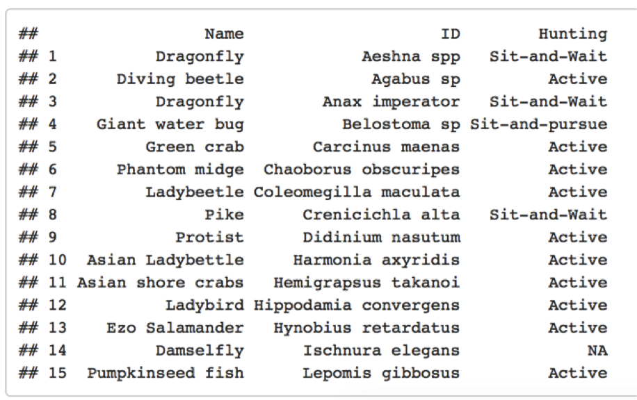

## O pacote data.table

- Não foi criado por Hadley Wickham!;
- Importa dados de forma rápida;
- Também fornece algumas ferramentas para manipulação mais rápida de dados.

```r
install.packages("data.table")
```

```r
library(data.table)
args(fread)
```

```
## function (input = "", sep = "auto", sep2 = "auto", nrows = -1L,
##     header = "auto", na.strings = "NA", stringsAsFactors = FALSE,
##     verbose = getOption("datatable.verbose"), autostart = 1L,
##     skip = 0L, select = NULL, drop = NULL, colClasses = NULL,
##     integer64 = getOption("datatable.integer64"), dec = if (sep !=
##         ".") "." else ",", col.names, check.names = FALSE, encoding = "unknown",
##     strip.white = TRUE, showProgress = getOption("datatable.showProgress"),
##     data.table = getOption("datatable.fread.datatable"))
## NULL
```

## Comparando pacotes

Método tradicional de **salvar dados** pode ser mais rápido do que através de métodos implementados por outros pacotes.

```
##         write.table write_tsv
## user          1.849     3.354
## system        0.046     0.062
## elapsed       1.909     3.436
```

## Comparando pacotes

Métodos de **leitura de dados** implementado por outros pacotes são mais rápidos do que o método tradicional.

```
##         read.table read_excel read_tsv fread
## user         3.465      1.866    0.290 0.203
## system       0.043      0.501    0.023 0.009
## elapsed      3.522      2.464    0.332 0.218
```